# Extract Address Information and Collect State

```r
# make kable table with consistent formatting
make_table <- function(df, title = "", ...) {
  title <- paste0("<center><span style = 'font-size:110%;color:black'><b>",
                  title,
                  "</span></b><center>")
   as_tibble(df) %>%
    kbl(caption = title, ... ) %>%
    kable_material() %>%
    row_spec(row=0, background = "#43494C" , color = "white", bold = TRUE)
}
```

# Identify State of Each Company

```r
# load script for variable extraction from xml files
source(here("GET_VARS.R"))


# vector of all xml files
files <- dir(here("ballet_990_released_20230208"),
               full.names = TRUE)

# iterate over all files and extract the state of their address
# NOTE:
# the variable '/Return/ReturnData/IRS990EZ/BooksInCareOfDetail/USAddress/State'
# is extracted to account for the fact that one file has this variable under this
# xpath rather than the StateAbbreviationCd xpath
add <- map_df(files,
              ~get_df(filename =.x,
                      variables = c(
                        '//Return//ReturnHeader//BusinessName',
                        '//Return/ReturnHeader//ReturnTypeCd',
                        '//Return/ReturnData/IRS990/USAddress/StateAbbreviationCd',
                        '//Return/ReturnData/IRS990/BooksInCareOfDetail/USAddress/StateAbbreviationCd',
                        '/Return/ReturnData/IRS990EZ/BooksInCareOfDetail/USAddress/State'),
              names = c('name', 'type_code', 'business_state_cd', 'books_state_cd', 'books_state'))) %>%
  filter_ein()

# if business_state_cd is NA, use where they have bookings
add <- add %>%
  mutate(state = case_when(
    !is.na(business_state_cd) ~ business_state_cd,
    is.na(business_state_cd) & !is.na(books_state_cd) ~ books_state_cd,
    is.na(business_state_cd) & is.na(books_state_cd) ~ books_state
  ))

# (stable) company names from file
companies <- read_csv(here("data", "companies.csv")) %>%
  mutate(EIN = as.character(ein))%>%
  select(organization_name, EIN, ein) %>%
  distinct()


add <- add %>%
  left_join(companies)




# number that did not report for any year on file
no_business_cd <- add %>%
  mutate(name = tolower(name)) %>%
  group_by(EIN) %>%
  summarize(business_state_cd = list(unique(na.omit(business_state_cd))),
            num_states = map_dbl(business_state_cd, length),
            name = paste(unique(name), collapse = ", ")) %>%
  filter(num_states == 0)
```

## Missingness in State Reported

The ideal classification of state is when we have the Business Address `IRS990/USAddress/StateAbbreviationCd`.

However, are 25 states that do not report the business state code in any year on file. These companies are:

providence ballet theatre  
catskill ballet theatre company inc  
ballet oklahoma inc  
tampa city ballet inc  
luminario ballet of los angeles  
ballet misha  
ballet nebraska  
texture contemporary ballet  
missouri contemporary ballet  
morballet inc  
lemonspongecake contemporary balletco jennifer sher  
savannah ballet theatre inc  
florida ballet at jacksonville inc  
brandon ballet inc  
the montgomery civic ballet inc  
ballet inc  
ballet san antonio  
bay pointe ballet  
new chamber ballet inc  
ballet north texas  
complexions foundationc/o complexions  
east coast contemporary ballet company  
the rosin box project inc  
chamberdance inc  
pacific festival ballet company inc.

For these companies, we set the state to where the company has their bookings, that is, `BooksInCareOfDetail/USAddress/StateAbbreviationCd`.

## Changes in State Reported

2 companies changed in geographic state:

```r
# two EINs had a change in business
add %>% group_by(EIN) %>%
  mutate(states = n_distinct(state)) %>%
  filter(states>1) %>%
  select(EIN, organization_name, business_state_cd,
         books_state_cd, fiscal_year)
```

| EIN | organization_name | business_state_cd | books_state_cd | fiscal_year |
| --- | --- | --- | --- | --- |
| 454864757 | Dissonance Dance Theatre | NA | DC | 2015 |
| 454864757 | Dissonance Dance Theatre | NA | UT | 2016 |
| 454864757 | Dissonance Dance Theatre | DC | DC | 2018 |
| 454864757 | Dissonance Dance Theatre | DC | DC | 2019 |
| 454864757 | Dissonance Dance Theatre | DC | DC | 2020 |
| 813872831 | Ballet Sun Valley | CA | ID | 2017 |
| 813872831 | Ballet Sun Valley | CA | ID | 2018 |
| 813872831 | Ballet Sun Valley | CA | ID | 2019 |
| 813872831 | Ballet Sun Valley | ID | ID | 2021 |

```r
add <- add %>%
  group_by(EIN) %>%
  arrange(fiscal_year) %>%
  mutate(business_state_cd = list(unique(na.omit(business_state_cd))),
         state_cd = map_chr(business_state_cd,
                            ~ifelse(length(.x) == 0,
                                    NA,
                                    .x[length(.x)])))


add %>%
  select(EIN,
         name,
         organization_name,
         business_state_cd = state_cd,
         books_state_cd,
         state) %>%
  saveRDS(here('data', 'ein_to_state.RDS'))

# check there is one state per EIN
 # add %>%
 #   group_by(EIN) %>%
 #  mutate(states = n_distinct(state)) %>%
 #  filter(states>1)
```

## Number of Companies by State

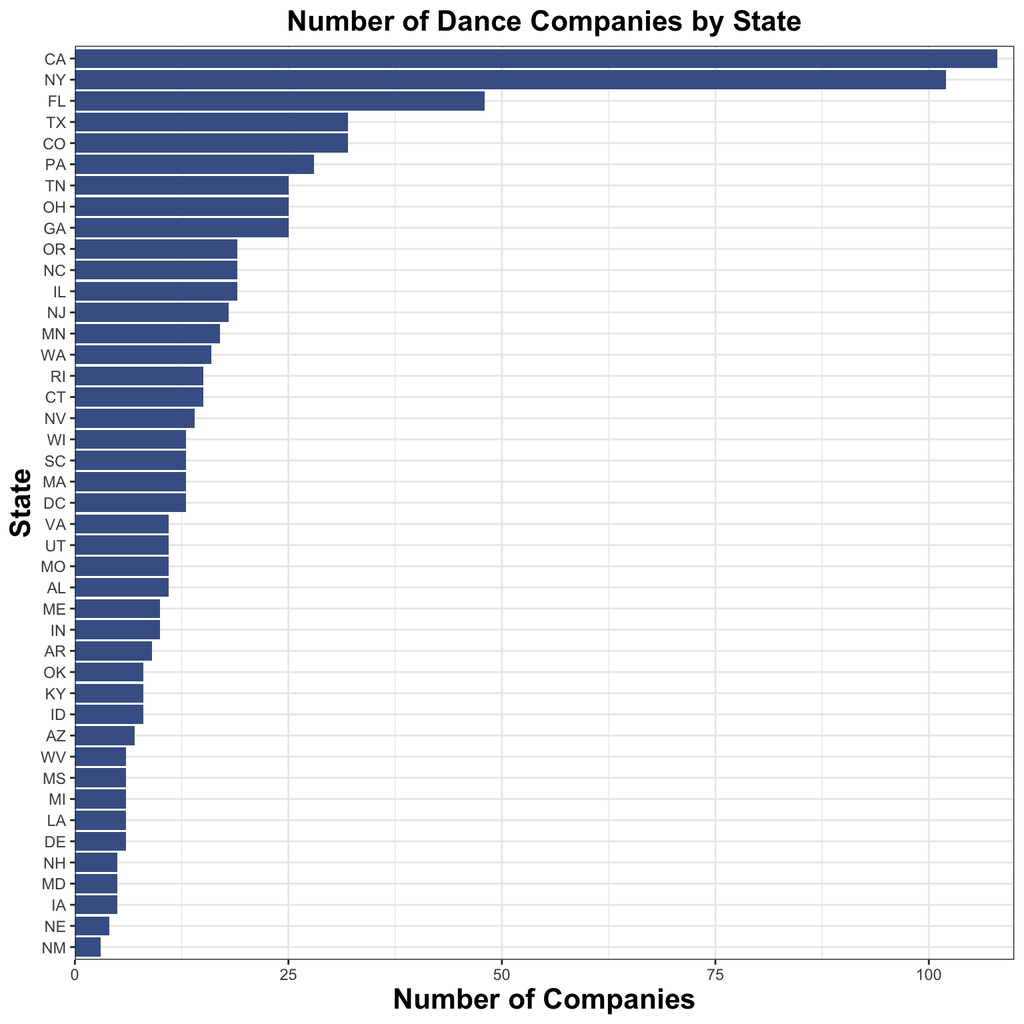

```r
counts_by_state <- add %>%
  group_by(state) %>%
  summarize(n_ein = n())

state_pop_link <- "https://www2.census.gov/programs-surveys/popest/datasets/2020-2022/state/totals/NST-EST2022-ALLDATA.csv"


if(!exists( here("data", "state_population.RDS"))) {
  state_pop <- read_csv(state_pop_link) %>%
  select(fips = STATE, pop = POPESTIMATE2022, state_name = NAME)

  state_fips <- read_csv(here("data", "state_fips.csv"))

  state_pop <- state_pop %>%
    inner_join(state_fips)

  saveRDS(state_pop, here("data", "state_population.RDS"))
}

state_pop <- readRDS(here("data", "state_population.RDS"))

#############################################
# plot number of companies for each state
#############################################

# raw counts of number of ein's by state
counts_by_state %>%
  ggplot(aes(x=fct_reorder(state,n_ein),  y = n_ein)) +
  geom_bar(stat="identity", fill = "#466094") +
  theme_bw() +
  theme(axis.title = element_text(size = 16, face = "bold"),
        plot.title = element_text(size = 16, face = "bold", hjust = .5)) +
  labs(y = "Number of Companies",
       x = "State",
       title = "Number of Dance Companies by State") +
  scale_y_continuous(expand = c(0,0),
                     limits = c(0,  max(counts_by_state$n_ein) + 2)) +
  coord_flip()
```

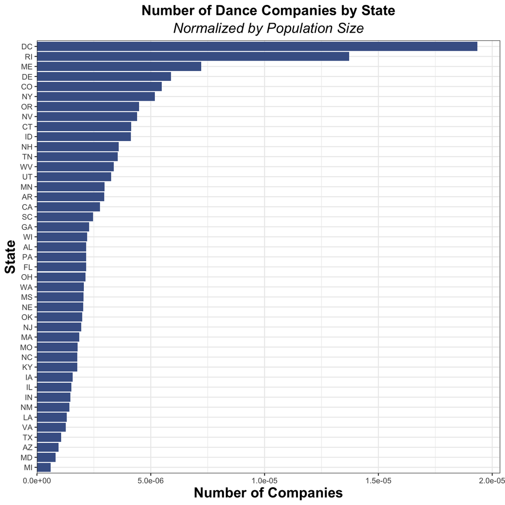

```r
counts_by_state <- counts_by_state %>%
  inner_join(state_pop) %>%
  mutate(n_ein_normalized = n_ein/pop)


# counts of number of eins by state normalized by population size
counts_by_state %>%
  ggplot(aes(x=fct_reorder(state,n_ein_normalized),  y = n_ein_normalized)) +
  geom_bar(stat="identity", fill = "#466094") +
  theme_bw() +
  theme(axis.title = element_text(size = 16, face = "bold"),
        plot.title = element_text(size = 16, face = "bold", hjust = .5),
        plot.subtitle = element_text(size = 16, face = "italic", hjust = .5)) +
  labs(y = "Number of Companies",
       x = "State",
       title = "Number of Dance Companies by State",
       subtitle = "Normalized by Population Size") +
  scale_y_continuous(expand = c(0,0),
                     limits = c(0,
                                max(counts_by_state$n_ein_normalized) + 10^(-6))) +
  coord_flip()
```

# Policy Data Sources

## CDC Policy Data

```r
# verify there is a state for each EIN
# add %>% filter(is.na(state))

link <- "https://healthdata.gov/resource/gyqz-9u7n.json"
cdc <- httr::GET("https://healthdata.gov/resource/gyqz-9u7n.json?policy_level='state'&$limit=6000")

cdc <- jsonlite::fromJSON(
  httr::content(cdc,
                as = "text",
                encoding = "UTF-8"),
  simplifyVector = TRUE,
  flatten = TRUE) %>%
  as_tibble() %>%
  select(state = state_id, date, policy_type, start_stop, comments, source) %>%
  mutate(date = lubridate::as_date(substr(date,1,10), format= "%Y-%m-%d")) %>%
  # only include states we have in the dance data
  filter(state %in% add$state)

# cdc %>% pull(policy_type) %>% unique()


cdc %>%
  group_by(policy_type) %>%
  summarize(n=n()) %>%
  arrange(desc(n))
```

| policy_type | n |
| --- | --- |
| Non-Essential Businesses | 93 |
| Food and Drink | 92 |
| Shelter in Place | 84 |
| Gyms | 83 |
| Entertainment | 79 |
| Childcare (K-12) | 70 |
| Outdoor and Recreation | 69 |
| Phase 2 | 69 |
| Houses of Worship | 62 |
| Mask Requirement | 58 |

[output cut: 43 more lines]

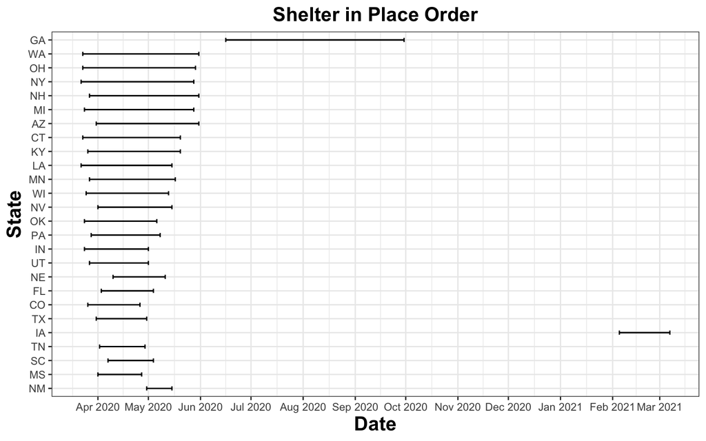

```r
#############################################
# non-essential businesses
#############################################
# seems unclear what these policies really mean
non_ess <- cdc %>%
  filter(policy_type == "Non-Essential Businesses") %>%
  select(-comments) %>%
  distinct() %>%
  pivot_wider(id_cols = c(state,policy_type,source),
              names_from = start_stop, values_from = date) %>%
  filter(!is.na(stop) & !is.na(start))


#############################################
# shelter in place orders
#############################################
shelter_in_place <- cdc %>%
  filter(policy_type == "Shelter in Place") %>%
  pivot_wider(id_cols = c(state,policy_type,source),
              names_from = start_stop, values_from = date) %>%
  filter(!is.na(stop) & !is.na(start))

shelter_in_place %>%
  mutate(length = difftime(stop,start)) %>%
  ggplot(aes(xmin = start, xmax = stop, y = fct_reorder(state,length))) +
  geom_linerange() +
   geom_errorbar(width = .3) +
   scale_x_date(date_breaks = "1 months", date_labels = "%b %Y") +
  theme_bw() +
  theme(axis.title = element_text(size = 16, face = "bold"),
        plot.title = element_text(size = 16, face = "bold", hjust = .5),
        plot.subtitle = element_text(size = 16, face = "italic", hjust = .5)) +
  labs(y = "State",
       x = "Date",
       title = "Shelter in Place Order")
```

## BU Policy Data

Data Source: BU COVID-19 US state policy database. More information on github [here](https://github.com/USCOVIDpolicy/COVID-19-US-State-Policy-Database).

- On [California’s long stay-at-home-order](https://apnews.com/article/california-lifts-stay-home-order-virus-1c298c67338a5914f7c3857cd167edcc)

Cleaned files generated in this section:

### Stay at Home Order

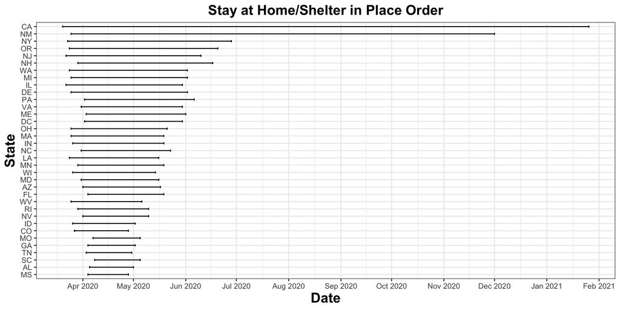

```r
################################
# STAY AT HOME ORDER
################################

if(!exists(here('data', 'stay_at_home_bu.RDS'))) {
  stay_at_home <- read_excel(here("data", "bu_data.xlsx"), sheet ='Stay at Home') %>%
  select(state = `State Abbreviation`,
         stay_at_home_start = `Stay at home/shelter in place`,
         stay_at_home_end = `End stay at home/shelter in place`,
   ) %>%
  mutate(across(c(stay_at_home_start,stay_at_home_end), ~ as_date(., origin="1899-12-31"))) %>%
  filter(!is.na(state)) %>%
    # if dates are input as 0, excel codes these as 1899-12-31; remove these
  filter(state %in% add$state & stay_at_home_start != "1899-12-31" & stay_at_home_end != "1899-12-31") %>%
  mutate(length_of_order =difftime(stay_at_home_end, stay_at_home_start, units="days") )

  saveRDS(stay_at_home, here('data', 'stay_at_home_bu.RDS'))

}

stay_at_home <- readRDS(here('data', 'stay_at_home_bu.RDS'))

 stay_at_home %>%
   ggplot(aes(xmin = stay_at_home_start, xmax = stay_at_home_end, y = fct_reorder(state,length_of_order))) +
   geom_errorbar(width = .3) +
   scale_x_date(date_breaks = "1 months", date_labels = "%b %Y") +
  theme_bw() +
  theme(axis.title = element_text(size = 16, face = "bold"),
        plot.title = element_text(size = 16, face = "bold", hjust = .5),
        plot.subtitle = element_text(size = 16, face = "italic", hjust = .5)) +
  labs(y = "State",
       x = "Date",
       title = "Stay at Home/Shelter in Place Order")
```

### State of Emergency

Some missing data here.

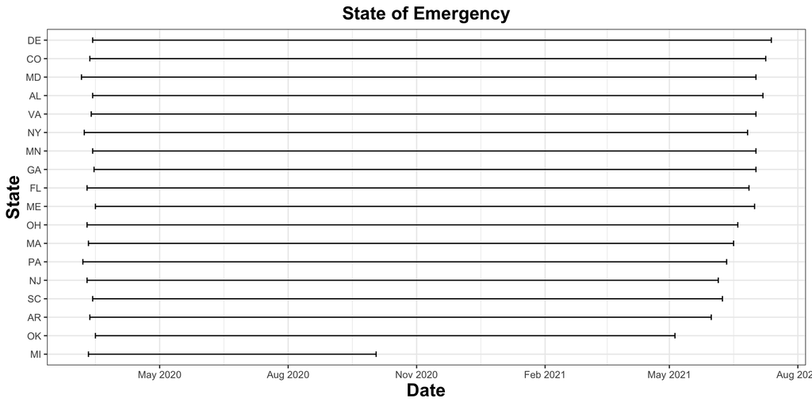

```r
################################
# STATE OF EMERGENCY
################################

if(!exists(here('data', 'state_of_emergency_bu.RDS'))) {
  state_of_emergency <- read_excel(here("data", "bu_data.xlsx"), sheet ='State of Emergency') %>%
  select(state = `State Abbreviation`,
         emergency_start = `State of emergency issued`,
         emergency_end = `State of emergency lifted`
   ) %>%
  mutate(across(c(emergency_start,emergency_end),~ as_date(., origin="1899-12-31"))) %>%
  filter(!is.na(state)) %>%
        # if dates are input as 0, excel codes these as 1899-12-31; remove these
  filter(state %in% add$state & emergency_start != "1899-12-31" & emergency_end != "1899-12-31") %>%
  mutate(length_of_order =difftime(emergency_end, emergency_start, units="days") )

  saveRDS(state_of_emergency, here('data', 'state_of_emergency_bu.RDS'))

}

emergency <- readRDS(here('data', 'state_of_emergency_bu.RDS'))

 emergency %>%
   ggplot(aes(xmin = emergency_start, xmax = emergency_end, y = fct_reorder(state,length_of_order))) +
   geom_errorbar(width = .3) +
   scale_x_date(date_breaks = "3 months", date_labels = "%b %Y") +
  theme_bw() +
  theme(axis.title = element_text(size = 16, face = "bold"),
        plot.title = element_text(size = 16, face = "bold", hjust = .5),
        plot.subtitle = element_text(size = 16, face = "italic", hjust = .5)) +
  labs(y = "State",
       x = "Date",
       title = "State of Emergency")
```

## KFF Policy Data

### Various Social Distancing Orders

Source: [Kaiser Family Foundation Data](https://github.com/KFFData/COVID-19-Data).

```r
dance_states <- add %>%
  left_join(state_pop) %>%
  pull(state_name) %>%
  unique()

if(!exists(here('data', 'social_dist_kff.RDS')))
{
  social <- read_excel(here("data", "social_distancing_kff.xlsx"), skip=1) %>%
  # replace dashes or spaces with underscores
  rename_with(.cols=everything(),
              ~tolower(gsub(" |-", "_", .x))) %>%
  # columns with numbers correspond to rollback dates; rename accordingly
  rename_with(.cols=matches("[[:digit:]]"),
              ~gsub("[[:digit:]]","_rollback", .)) %>%
  select(-primary_election_postponement) %>%
  # we have to do this separately because some are datetime and some are character
  # conversion is slightly different (no origin needed for datetime)
  mutate(across(-c(where(is.POSIXct),state),
                    ~as_date(as.numeric(.x), origin = "1899-12-31"))) %>%
  mutate(across(where(is.POSIXct),
                    ~as_date(.x)))


  social <- social %>%
    pivot_longer(-state) %>%
    mutate(start_stop = ifelse(grepl("rollback", name), "stop", "start"),
           name = gsub("_rollback", '', name)) %>%
    pivot_wider(names_from = c(start_stop), values_from = value) %>%
    mutate(length = difftime(stop,start, "days")) %>%
    rename(policy = name)

  # only include states in our dance data
  social <- social %>%
    filter(state %in% dance_states)

  # save file
  saveRDS(social, here('data', 'social_dist_kff.RDS'))
}

social <- readRDS(here('data', 'social_dist_kff.RDS'))
```

```r
# fill in missing values with stay_at_home BU data
miss <- social %>%
  filter(( is.na(stop) | is.na(start)) & policy == "stay_at_home_order")  %>%
  rename(state_name =state) %>%
  left_join(state_pop, by = c('state_name' = 'state_name'))


fill <- stay_at_home %>%
  filter(state %in% miss$state) %>%
  rename(start = stay_at_home_start,
         stop = stay_at_home_end) %>%
  select(state,stop,start) %>%
  left_join(state_pop) %>%
  select(-c(state, fips,pop)) %>%
  mutate(policy = "stay_at_home_order")


social <- social %>%
  left_join(fill, by =c('state'="state_name", 'policy'='policy')) %>%
  mutate(stop = ifelse(is.na(stop.x), stop.y, stop.x),
         start = ifelse(is.na(start.x), start.y, start.x)) %>%
  select(-c(stop.x,stop.y, start.x,start.y)) %>%
  mutate(across(c(stop, start), as_date))
```

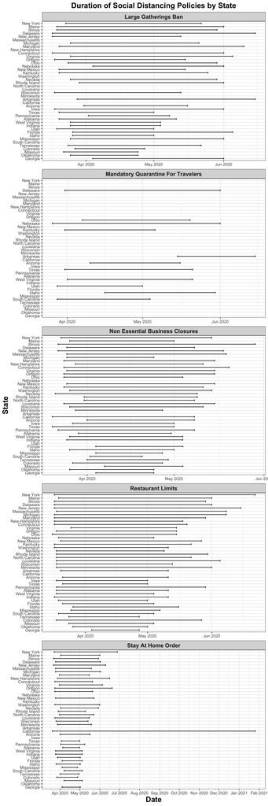

```r
# plot length of orders by state
social %>%
  filter(!is.na(start) & !is.na(stop)) %>%
  # reformat policy names
  mutate(policy = gsub("_", " ", policy),
         policy = str_to_title(policy)) %>%
  ggplot(aes(xmin = start, xmax = stop, y = fct_reorder(state,length))) +
   geom_errorbar(width = .5) +
   scale_x_date(date_breaks = "1 month", date_labels = "%b %Y") +
  theme_bw() +
  theme(axis.title = element_text(size = 16, face = "bold"),
        plot.title = element_text(size = 16, face = "bold", hjust = .5),
        plot.subtitle = element_text(size = 16, face = "italic", hjust = .5),
        strip.text = element_text(size = 12, face= "bold")) +
  labs(y = "State",
       x = "Date",
       title = "Duration of Social Distancing Policies by State") +
  facet_wrap(~policy, nrow = 5, scales = "free_x")
```

### Missingness by Social Distancing Policy

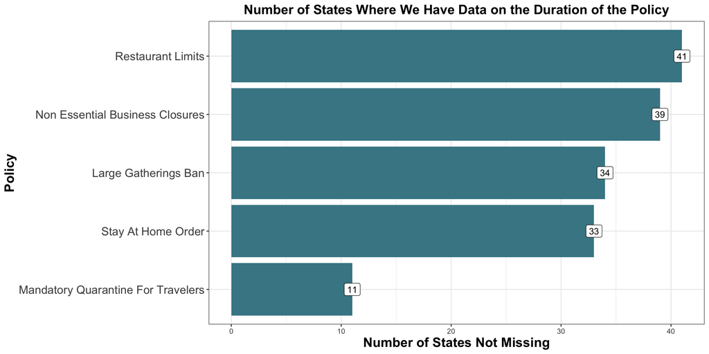

```r
social %>%
  mutate(policy = gsub("_", " ", policy),
         policy = str_to_title(policy)) %>%
  filter(!is.na(length)) %>%
  group_by(policy) %>%
  summarize(n_states = n()) %>%
  ggplot(aes(x =fct_reorder(policy, n_states),
             y = n_states)) +
  labs(x="Policy", y = "Number of States Not Missing",
       title = "Number of States Where We Have Data on the Duration of the Policy") +
  geom_bar(stat="identity", fill = "#468794") +
  geom_label(aes(label = n_states)) +
  theme_bw() +
  theme(axis.title = element_text(size = 16, face = "bold"),
        axis.text.y = element_text(size = 14),
        plot.title = element_text(size = 16, face = "bold", hjust = .5),
        plot.subtitle = element_text(size = 16, face = "italic", hjust = .5),
        strip.text = element_text(size = 12, face= "bold"))  +
  coord_flip()
```